# Bayesian Regression Models with RStanARM

TJ Mahr  
Sept. 21, 2016

Madison R Users Group

[Github repository](https://github.com/tjmahr/MadR_RStanARM)  
[@tjmahr](https://twitter.com/tjmahr)

### Overview

- [How I got into Bayesian statistics](http://rpubs.com/tjmahr/rep-crisis)
- [Some intuition-building about Bayes theorem](http://rpubs.com/tjmahr/bayes-theorem)
- **[Tour of RStanARM](http://rpubs.com/tjmahr/rstanarm-tour)**
- [Where to learn more about Bayesian statistics](http://rpubs.com/tjmahr/bayes-learn-more)

## Tour of RStanARM

## Software ecosystem

### What is Stan?

A programming language for probablistic stats.

- Write out a description of the data and model using a mathy syntax.
- The model is *compiled* into an executable that does the sampling.
- Pystan and RStan are interfaces that help you send/receive data to/from Stan models.

### Simple Regression Model in Stan

```r
# R version
lm(log(earnings) ~ height + male)
```

```
data {
  int<lower=0> N;
  vector[N] earn;
  vector[N] height;
  vector[N] male;
}
transformed data {
  // log transformation
  vector[N] log_earn;
  log_earn = log(earn);
}
parameters {
  vector[3] beta;
  real<lower=0> sigma;
}
model {
  log_earn ~ normal(beta[1] + beta[2] * height + beta[3] * male, sigma);
}
generated quantities {
  // optional
}
```

### Take aways

- Program is a description of the data and a model.
- Language wants a more formal information about the data (type, length, bounds), presumably for more efficient sampling.
- The tilde operator `~` is a sampling statement.

### Another language?

[figure not shown]

## RStanARM

### What is RStanArm?

RStan Applied Regression Modeling

- Batteries-included, precompiled versions of common regression models.
- `glm` -> `stan_glm`, `glmer` -> `stan_glmer`.
- Write your regular code. Add `stan_` to the front, and add a prior.
- [CRAN page](https://cran.r-project.org/web/packages/rstanarm/)
  - Very good! They have lots of detailed vignettes!
- Proper successor to the `arm` package.

### An example: Height and Weight by Sex

```r
# Some toy data
davis <- car::Davis %>% filter(100 < height) %>% as_data_frame

davis
```

```
#> # A tibble: 199 × 5
#>       sex weight height repwt repht
#>    <fctr>  <int>  <int> <int> <int>
#> 1       M     77    182    77   180
#> 2       F     58    161    51   159
#> 3       F     53    161    54   158
#> 4       M     68    177    70   175
#> 5       F     59    157    59   155
#> 6       M     76    170    76   165
#> 7       M     76    167    77   165
#> 8       M     69    186    73   180
#> 9       M     71    178    71   175
#> 10      M     65    171    64   170
#> # ... with 189 more rows
```

### Classical model: Summary

```r
model <- lm(weight ~ height * sex, davis)
summary(model) %>% print(digits = 2)
```

```
#>
#> Call:
#> lm(formula = weight ~ height * sex, data = davis)
#>
#> Residuals:
#>    Min     1Q Median     3Q    Max
#>  -20.9   -4.8   -0.9    4.5   41.1
#>
#> Coefficients:
#>             Estimate Std. Error t value Pr(>|t|)
#> (Intercept)   -45.71      22.19    -2.1     0.04 *
#> height          0.62       0.13     4.6    7e-06 ***
#> sexM          -55.62      32.54    -1.7     0.09 .
#> height:sexM     0.37       0.19     2.0     0.05 .
#> ---
#> Signif. codes:  0 '***' 0.001 '**' 0.01 '*' 0.05 '.' 0.1 ' ' 1
#>
#> Residual standard error: 8 on 195 degrees of freedom
#> Multiple R-squared:  0.64,   Adjusted R-squared:  0.64
#> F-statistic: 1.2e+02 on 3 and 195 DF,  p-value: <2e-16
```

### Classical model: Predicted mean over x

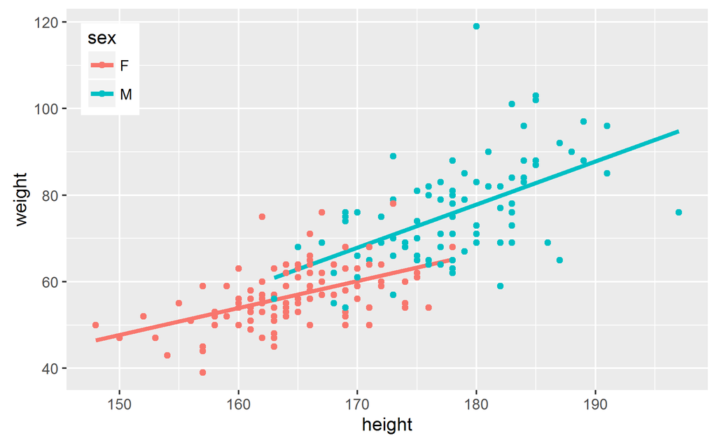

## Fitting the model with RStanARM

### Load the package

```r
library(rstanarm)
```

### Fit the model

- We have to use `stan_glm()`.
  - `stan_lm()` uses a different specification of the prior.
- By default, it does sampling with 4 MCMC chains.
  - Each chain is 2000 samples, but the first half are warm-up samples.
  - Warm-up samples are ignored.

```r
stan_model <- stan_glm(
  weight ~ height * sex,
  data = davis,
  family = gaussian,
  prior = normal(location = 0, scale = 5),
  prior_intercept = normal(0, 10)
)
```

[output not shown]

[output cut: 16 more lines]

[output not shown]

```r
# comment to make the bottom of the output visible
```

### First look: Just printing the model object

```r
stan_model
```

```
#> stan_glm(formula = weight ~ height * sex, family = gaussian,
#>     data = davis, prior = normal(location = 0, scale = 5), prior_intercept = normal(0,
#>         10))
#>
#> Estimates:
#>             Median MAD_SD
#> (Intercept) -48.1   21.5
#> height        0.6    0.1
#> sexM        -49.9   29.8
#> height:sexM   0.3    0.2
#> sigma         8.0    0.4
#>
#> Sample avg. posterior predictive
#> distribution of y (X = xbar):
#>          Median MAD_SD
#> mean_PPD 65.3    0.8
#>
#> Observations: 199  Number of unconstrained parameters: 5
```

### Getting a summary from the model

```r
summary(stan_model)
```

```
#> stan_glm(formula = weight ~ height * sex, family = gaussian,
#>     data = davis, prior = normal(location = 0, scale = 5), prior_intercept = normal(0,
#>         10))
#>
#> Family: gaussian (identity)
#> Algorithm: sampling
#> Posterior sample size: 4000
#> Observations: 199
#>
#> Estimates:
#>                 mean   sd     2.5%   25%    50%    75%    97.5%
#> (Intercept)    -48.2   21.4  -90.7  -62.3  -48.1  -33.2   -8.1
#> height           0.6    0.1    0.4    0.5    0.6    0.7    0.9
#> sexM           -50.0   30.7 -110.2  -70.5  -49.9  -30.6   12.3
#> height:sexM      0.3    0.2    0.0    0.2    0.3    0.5    0.7
#> sigma            8.0    0.4    7.3    7.7    8.0    8.3    8.9
#> mean_PPD        65.3    0.8   63.7   64.8   65.3   65.9   66.9
#> log-posterior -708.8    1.6 -712.7 -709.6 -708.5 -707.6 -706.7
#>
#> Diagnostics:
#>               mcse Rhat n_eff
#> (Intercept)   0.6  1.0  1254
#> height        0.0  1.0  1258
#> sexM          0.9  1.0  1086
#> height:sexM   0.0  1.0  1070
#> sigma         0.0  1.0  2092
#> mean_PPD      0.0  1.0  2562
#> log-posterior 0.0  1.0  1441
#>
#> For each parameter, mcse is Monte Carlo standard error, n_eff is a crude measure of effective sample size, and Rhat is the potential scale reduction factor on split chains (at convergence Rhat=1).
```

```r
# comment to make the bottom of the output visible
```

### Notes on summary()

- Split into estimation and diagnostic information
- `mean_PPD` is the predicted value for a completely average observation

## Inspecting posterior samples

### Looking at the posterior parameter samples

Coerce to a data-frame. Columns are parameters. One row per posterior sample.

```r
samples <- stan_model %>% as.data.frame %>% tbl_df
samples
```

```
#> # A tibble: 4,000 × 5
#>    `(Intercept)`    height       sexM `height:sexM`    sigma
#>            <dbl>     <dbl>      <dbl>         <dbl>    <dbl>
#> 1      -56.71142 0.6895427 -68.550433    0.44384885 7.537152
#> 2      -56.70521 0.6909141 -69.411803    0.44392578 7.784114
#> 3      -56.34580 0.6865143 -69.497981    0.44949406 7.795977
#> 4      -30.71059 0.5202990 -58.429948    0.40582612 7.991750
#> 5      -34.68467 0.5452743 -64.090664    0.42866842 7.784008
#> 6      -87.38731 0.8865953   2.711235    0.02298263 8.324237
#> 7      -98.27211 0.9459078  15.229156   -0.05056481 8.665427
#> 8      -58.71536 0.6977810 -13.289139    0.13100168 7.894166
#> 9      -63.19315 0.7205729 -22.734855    0.17883580 8.501026
#> 10     -71.94144 0.7791263 -52.550236    0.33906170 8.051117
#> # ... with 3,990 more rows
```

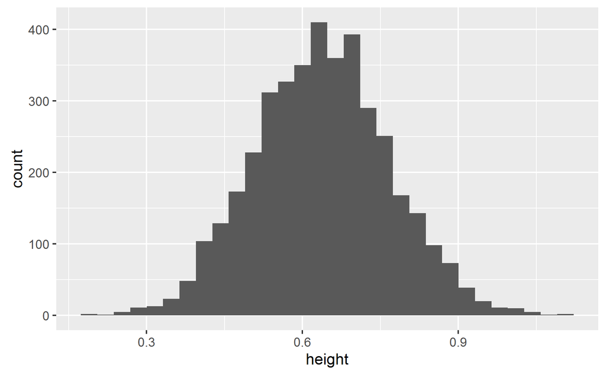

```r
ggplot(samples) + aes(x = height) + geom_histogram()
```

### Quantiles are post-data probabilities

- If we believe there is a “true” value for a parameter, there is 90% probability that this “true” value is in the 90% interval, given our model, prior information, and the data.
- The 90% interval contains the middle 90% of the parameter values.
  - There is a 5% chance, says the model, the height parameter is below the 5% quantile.

```r
posterior_interval(stan_model)
```

```
#>                        5%         95%
#> (Intercept)  -84.07171214 -13.2795824
#> height         0.42566160   0.8566897
#> sexM        -100.94954649   0.7700961
#> height:sexM    0.04578185   0.6331447
#> sigma          7.41023334   8.7265783
```

### Plotting the parameters

Basic `plot()` method shows 80% and 95% intervals.

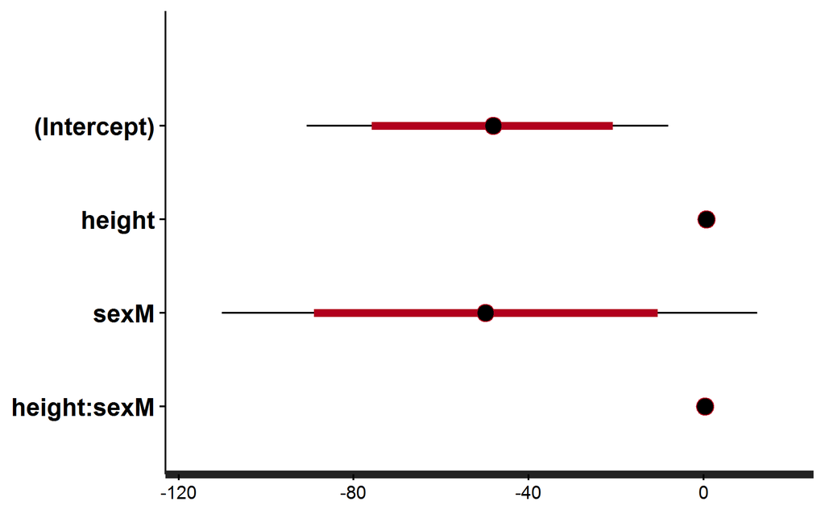

```r
plot(stan_model)
```

### Plotting some of the parameters

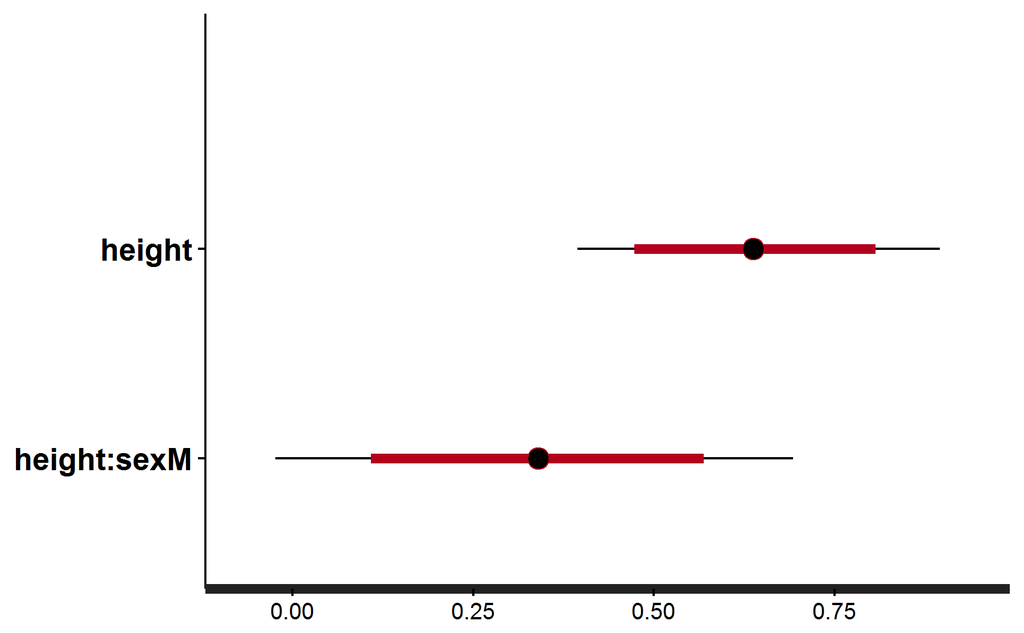

```r
# Match a subset of the parameters
plot(stan_model, regex_pars = "height")
```

### Exploring with ShinyStan

This thing is pretty awesome.

```r
launch_shinystan(stan_model)
```

[*Demo outside of slides.*]

### Things I just demonstrated in ShinyStan

- Diagnostics
  - Mixing of chains
  - R hat, n eff
  - PPcheck
- Parameters plot
  - Different parameters selected
  - KDE
- Explore
  - Inspect one parameter in multiview
  - Bivariate view

## Plotting model results

### Doing Things With The Model

Get a data-frame with the parameters from each sample. We now have 4000 plausble regression lines.

```r
df_model <- stan_model %>% as_data_frame()
df_model
```

```
#> # A tibble: 4,000 × 5
#>    `(Intercept)`    height       sexM `height:sexM`    sigma
#>            <dbl>     <dbl>      <dbl>         <dbl>    <dbl>
#> 1      -56.71142 0.6895427 -68.550433    0.44384885 7.537152
#> 2      -56.70521 0.6909141 -69.411803    0.44392578 7.784114
#> 3      -56.34580 0.6865143 -69.497981    0.44949406 7.795977
#> 4      -30.71059 0.5202990 -58.429948    0.40582612 7.991750
#> 5      -34.68467 0.5452743 -64.090664    0.42866842 7.784008
#> 6      -87.38731 0.8865953   2.711235    0.02298263 8.324237
#> 7      -98.27211 0.9459078  15.229156   -0.05056481 8.665427
#> 8      -58.71536 0.6977810 -13.289139    0.13100168 7.894166
#> 9      -63.19315 0.7205729 -22.734855    0.17883580 8.501026
#> 10     -71.94144 0.7791263 -52.550236    0.33906170 8.051117
#> # ... with 3,990 more rows
```

Apply the group effects to get regression lines for each sex.

```r
df_model2 <- df_model %>%
  mutate(F_Intercept = `(Intercept)`, F_Slope = height,
         M_Intercept = `(Intercept)` + sexM,
         M_Slope = height + `height:sexM`) %>%
  select(F_Intercept:M_Slope)
df_model2
```

```
#> # A tibble: 4,000 × 4
#>    F_Intercept   F_Slope M_Intercept   M_Slope
#>          <dbl>     <dbl>       <dbl>     <dbl>
#> 1    -56.71142 0.6895427  -125.26185 1.1333915
#> 2    -56.70521 0.6909141  -126.11701 1.1348399
#> 3    -56.34580 0.6865143  -125.84378 1.1360084
#> 4    -30.71059 0.5202990   -89.14054 0.9261251
#> 5    -34.68467 0.5452743   -98.77534 0.9739427
#> 6    -87.38731 0.8865953   -84.67607 0.9095779
#> 7    -98.27211 0.9459078   -83.04295 0.8953430
#> 8    -58.71536 0.6977810   -72.00450 0.8287827
#> 9    -63.19315 0.7205729   -85.92801 0.8994087
#> 10   -71.94144 0.7791263  -124.49167 1.1181880
#> # ... with 3,990 more rows
```

### The "Pile of Lines" Plot

Plot lines with the median parameter values and a random sample of lines.

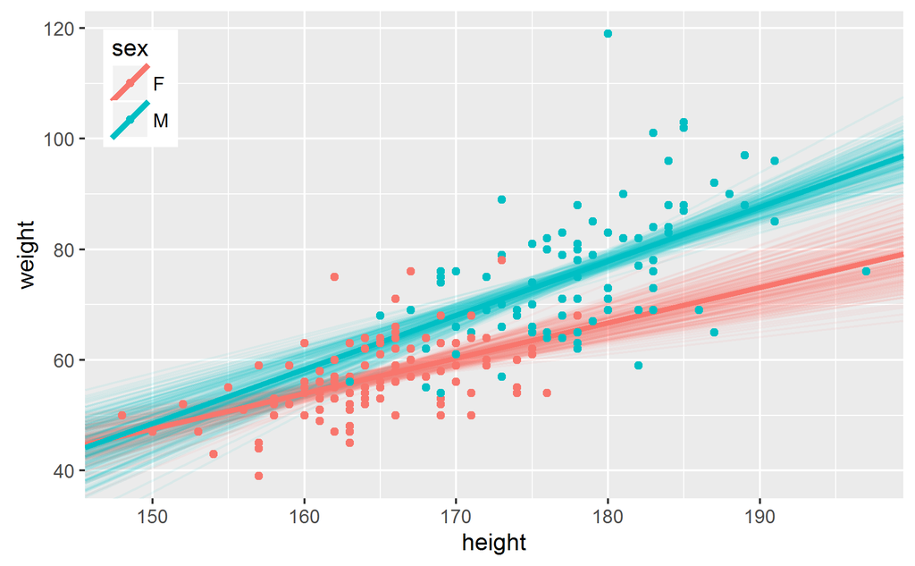

```r
fits <- sample_n(df_model2, 200)
medians <- df_model2 %>% summarise_each(funs = funs(median))

p2 <- ggplot(davis) +
  aes(x = height, y = weight, color = sex) +
  geom_abline(aes(color = "F", intercept = F_Intercept,
                  slope = F_Slope), data = fits, alpha = .075) +
  geom_abline(aes(color = "M", intercept = M_Intercept,
                  slope = M_Slope), data = fits, alpha = .075) +
  geom_abline(aes(color = "F", intercept = F_Intercept,
                  slope = F_Slope), data = medians, size = 1.25) +
  geom_abline(aes(color = "M", intercept = M_Intercept,
                  slope = M_Slope), data = medians, size = 1.25) +
  geom_point() +
  theme(legend.position = c(0, 1), legend.justification = c(0, 1))
```

### "Pile of Lines"

- Depicts uncertainty by drawing line of best fit plus many other plausible regression lines.
- Visualization works best when there is only one group and we don't mind having regression lines stretch past the range of the data.

### The "Line + Prediction Interval" Plot

Get a sample of height values within each group's range.

```r
# # do some stuff
# ...

new_data
```

```
#> # A tibble: 160 × 3
#>    Observation   sex   height
#>          <chr> <chr>    <dbl>
#> 1            1     F 148.0000
#> 2            2     F 148.3797
#> 3            3     F 148.7595
#> 4            4     F 149.1392
#> 5            5     F 149.5190
#> 6            6     F 149.8987
#> 7            7     F 150.2785
#> 8            8     F 150.6582
#> 9            9     F 151.0380
#> 10          10     F 151.4177
#> # ... with 150 more rows
```

### Get the predicted mean for each point

With the normal `predict()` function on a classical regression model, we use the model parameters to get the expected mean (\( \mu_i \)) for each row in `newdata`.

With `posterior_linpred()`, we do the same thing, but for each of the 4000 posterior samples.

```r
linpreds <- posterior_linpred(stan_model, newdata = new_data)
dim(linpreds)
```

```
#> [1] 4000  160
```

```r
# In long format... 4000 samples x 160 data points
tidy_linpreds <- linpreds %>%
  as_data_frame %>%
  tibble::rownames_to_column("Draw") %>%
  tidyr::gather(Observation, Value, -Draw)

tidy_linpreds
```

```
#> # A tibble: 640,000 × 3
#>     Draw Observation    Value
#>    <chr>       <chr>    <dbl>
#> 1      1           1 45.34089
#> 2      2           1 45.55008
#> 3      3           1 45.25832
#> 4      4           1 46.29367
#> 5      5           1 46.01592
#> 6      6           1 43.82879
#> 7      7           1 41.72225
#> 8      8           1 44.55623
#> 9      9           1 43.45163
#> 10    10           1 43.36925
#> # ... with 639,990 more rows
```

Summarize the posterior predictions for each new data point. Go from 4000 rows per new point to just one row per new data point.

```r
df_predictions <- tidy_linpreds %>%
  group_by(Observation) %>%
  summarise(median = median(Value),
            ymin = quantile(Value, .025),
            ymax = quantile(Value, .975)) %>%
  left_join(new_data)

df_predictions
```

```
#> # A tibble: 160 × 6
#>    Observation   median     ymin     ymax   sex   height
#>          <chr>    <dbl>    <dbl>    <dbl> <chr>    <dbl>
#> 1            1 46.26271 41.56672 50.55823     F 148.0000
#> 2           10 48.44859 44.61635 52.04461     F 151.4177
#> 3          100 69.23704 66.83380 71.73073     M 171.1772
#> 4          101 69.65821 67.32576 72.05880     M 171.6076
#> 5          102 70.09021 67.80754 72.40900     M 172.0380
#> 6          103 70.51185 68.29674 72.76241     M 172.4684
#> 7          104 70.93182 68.79742 73.11356     M 172.8987
#> 8          105 71.35920 69.29262 73.47099     M 173.3291
#> 9          106 71.78164 69.78014 73.83019     M 173.7595
#> 10         107 72.20361 70.23412 74.17940     M 174.1899
#> # ... with 150 more rows
```

### Now, we can plot predicted means

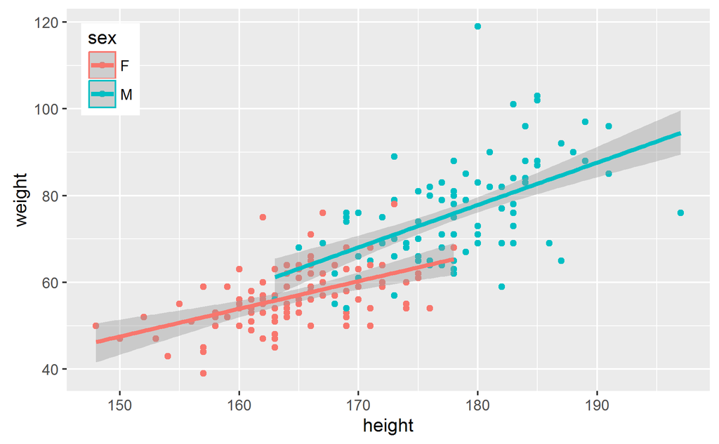

```r
p3 <- ggplot(davis) +
  aes(x = height, y = weight, color = sex, group = sex) +
  geom_point() +
  geom_ribbon(aes(ymin = ymin, ymax = ymax, y = NULL, color = NULL),
              data = df_predictions, fill = "grey60", alpha = .4) +
  geom_line(aes(y = median), data = df_predictions, size = 1.25) +
  theme(legend.position = c(0, 1), legend.justification = c(0, 1))
```

### Limitations of this approach

RStanARM does not like `posterior_linpred()`. Documentation says:

> **See also**: `posterior_predict` to draw from the posterior predictive distribution of the outcome, which is almost always preferable.

Why? Because we have samples of the error term `sigma`, and we're not using them!

### Get the model to generate new observations

Same plan as before, but use `posterior_predict()` to get predictions for observations (\( y_i \)), instead of estimates of the mean (\( \mu_i \)).

```r
# ?posterior_predict
preds <- posterior_predict(stan_model, newdata = new_data)
dim(preds)
```

```
#> [1] 4000  160
```

```r
tidy_preds <- preds %>%
  # Rename columns from V1, V2, ... to 1, 2, ...
  as_data_frame %>% setNames(seq_len(ncol(.))) %>%
  tibble::rownames_to_column("Draw") %>%
  tidyr::gather(Observation, Value, -Draw)

tidy_preds
```

```
#> # A tibble: 640,000 × 3
#>     Draw Observation    Value
#>    <chr>       <chr>    <dbl>
#> 1      1           1 48.09020
#> 2      2           1 56.69339
#> 3      3           1 43.43079
#> 4      4           1 45.32523
#> 5      5           1 52.31126
#> 6      6           1 49.02409
#> 7      7           1 45.03329
#> 8      8           1 36.15589
#> 9      9           1 51.22175
#> 10    10           1 67.86039
#> # ... with 639,990 more rows
```

```r
df_predictions <- tidy_preds %>%
  group_by(Observation) %>%
  summarise(median = median(Value),
            ymin = quantile(Value, .025),
            ymax = quantile(Value, .975)) %>%
  left_join(new_data)

df_predictions
```

```
#> # A tibble: 160 × 6
#>    Observation   median     ymin     ymax   sex   height
#>          <chr>    <dbl>    <dbl>    <dbl> <chr>    <dbl>
#> 1            1 46.20671 29.78864 63.33542     F 148.0000
#> 2           10 48.40533 32.28516 64.73203     F 151.4177
#> 3          100 69.18329 53.50192 84.44524     M 171.1772
#> 4          101 69.75366 53.64065 85.40446     M 171.6076
#> 5          102 69.82163 54.19379 85.86467     M 172.0380
#> 6          103 70.37902 54.75848 86.75807     M 172.4684
#> 7          104 71.01157 54.98491 86.40210     M 172.8987
#> 8          105 71.60191 55.75243 87.27941     M 173.3291
#> 9          106 71.55881 56.19622 87.82290     M 173.7595
#> 10         107 72.33715 55.81252 88.64755     M 174.1899
#> # ... with 150 more rows
```

### Plot the predictions

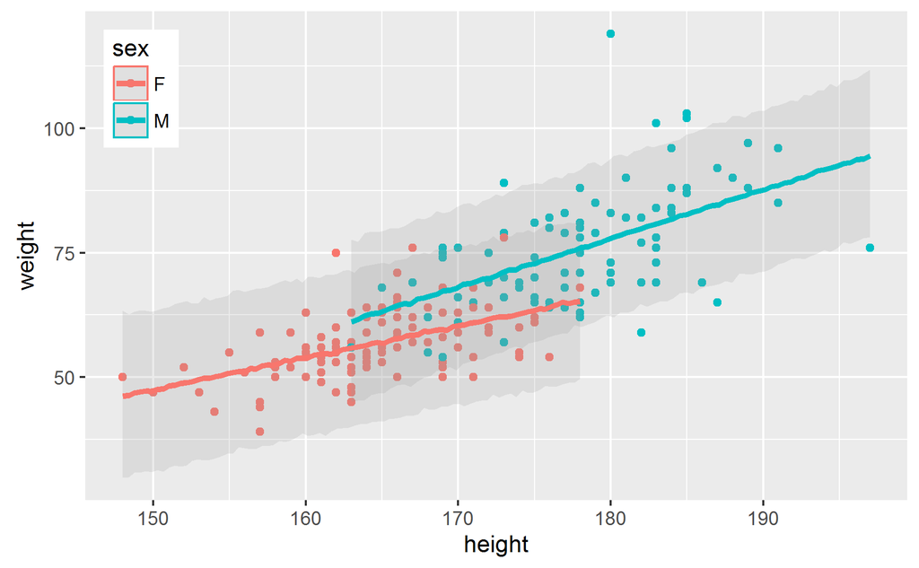

```r
p4 <- ggplot(davis) +
  aes(x = height, y = weight, color = sex, group = sex) +
  geom_point() +
  geom_ribbon(aes(ymin = ymin, ymax = ymax, y = NULL, color = NULL),
              data = df_predictions, fill = "grey60", alpha = .2) +
  geom_line(aes(y = median),
              data = df_predictions, size = 1.25) +
  theme(legend.position = c(0, 1), legend.justification = c(0, 1))
```

## Model comparison

### Model comparison

Do we need the sex-height interaction?

Do we need the sex predictor at all?

Let's fit alternative models.

```r
stan_model_no_inter <- update(stan_model, weight ~ sex + height)
stan_model_no_group <- update(stan_model, weight ~ height)
```

### Classical model comparison

For classical regression models, we could compare models with AIC and BIC.

```r
model_no_inter <- update(model, weight ~ sex + height)
model_no_group <- update(model, weight ~ height)
model_list <- list(
  no_group = model_no_group,
  no_inter = model_no_inter,
  inter = model)

model_list %>% lapply(AIC) %>% unlist
```

```
#> no_group no_inter    inter
#> 1421.572 1401.590 1399.692
```

```r
model_list %>% lapply(BIC) %>% unlist
```

```
#> no_group no_inter    inter
#> 1431.452 1414.764 1416.158
```

### Classical model comparison

Or with `anova()`.

```r
anova(model_no_group, model_no_inter, model)
```

```
#> Analysis of Variance Table
#>
#> Model 1: weight ~ height
#> Model 2: weight ~ sex + height
#> Model 3: weight ~ height * sex
#>   Res.Df   RSS Df Sum of Sq       F    Pr(>F)
#> 1    197 14312
#> 2    196 12815  1   1496.72 23.2250 2.892e-06 ***
#> 3    195 12567  1    248.64  3.8582   0.05092 .
#> ---
#> Signif. codes:  0 '***' 0.001 '**' 0.01 '*' 0.05 '.' 0.1 ' ' 1
```

### Approximate Leave One Out Cross Validation

For RStanARM, we compare the models by using approximation leave-one-out cross-validation. The details are outside of the scope of this talk.

```r
loo1 <- loo(stan_model_no_group)
loo2 <- loo(stan_model_no_inter)
loo3 <- loo(stan_model)
```

```r
compare(loo1, loo2, loo3)
```

```
#>      looic  se_looic elpd_loo se_elpd_loo p_loo  se_p_loo
#> loo3 1401.7   33.9   -700.8     16.9         6.7    2.1
#> loo2 1402.9   33.3   -701.5     16.6         5.3    1.9
#> loo1 1422.7   31.9   -711.3     15.9         4.2    1.7
```

- Like other IC, lower is better. Importantly, the LOOIC comes with a standard error.
- By point-value (`looic`), the model with the interaction is expected to perform the best on out-of-sample data.
- But the `se_looic` indicates considerable overlap with the model with no interaction term.
- Like so much of Bayesian modeling, uncertainty is everything.

## Comparing the model to the priors

### Priors

- In our models, the prior `normal(0, 5)` gets rescaled to match each predictor variable.
- This rescaling is [not well documented](https://groups.google.com/forum/#!category-topic/stan-users/rstanarm/_y6aDbkdANw).
- Some options:
  - `scale()` our measurements so that they are [scale free](https://github.com/stan-dev/stan/wiki/Prior-Choice-Recommendations) (with mean = 0 and SD = 1).
  - Sample from the prior to see what kinds of values are generated by our prior and confirm that our prior information yields sensible model behavior.

### Sampling from the prior: posterior_vs_prior()

RStanARM will compare samples from the posterior and the prior.

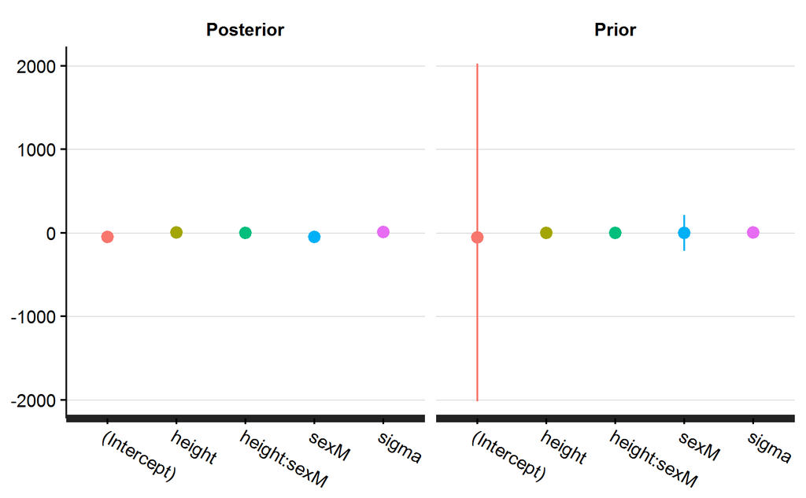

```r
posterior_vs_prior(stan_model)
```

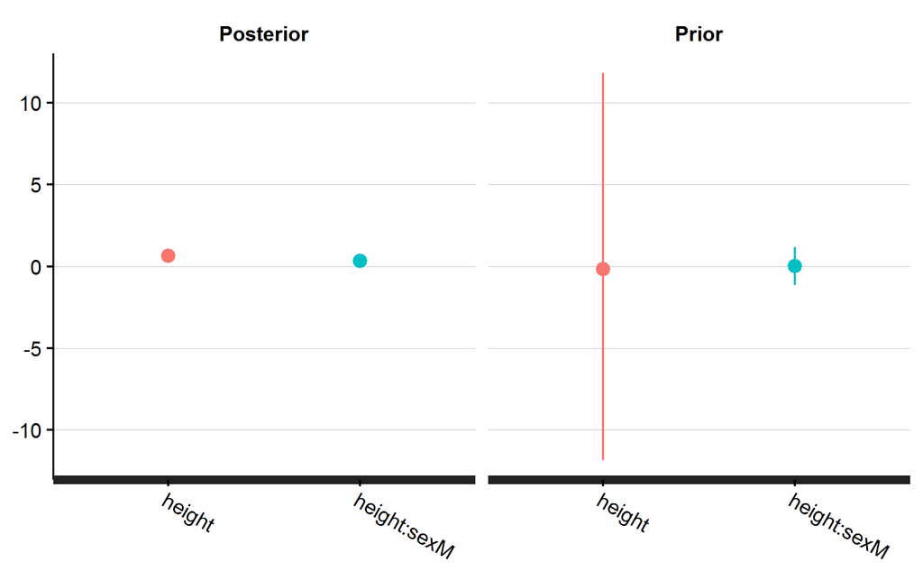

```r
# Select just parameters with "height" in the name
posterior_vs_prior(stan_model, regex_pars = "height")
```

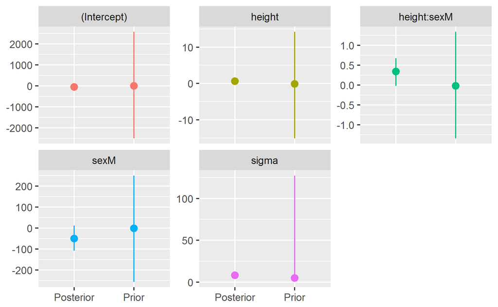

```r
# use the faceting options
comparison <- posterior_vs_prior(
  stan_model,
  group_by_parameter = TRUE,
  facet_args = list(scales = "free_y"),
  prob = .95)

comparison + theme_grey() + guides(color = FALSE)
```

### Sampling from the prior: prior_PD = TRUE

We can also sample from the prior directly.

```r
stan_model_prior <- stan_glm(
  weight ~ height * sex,
  data = davis,
  family = gaussian,
  prior = normal(0, 5),
  prior_intercept = normal(0, 10),
  # this line is new:
  prior_PD = TRUE
)
```

Our initial prior says that an increase in height of 1 cm may predict a 0 +/- 7 kg increase in weight in women. This is a very generous interval for this effect!

```r
summary(stan_model_prior, probs = c(.1, .5, .9))
```

```
#> stan_glm(formula = weight ~ height * sex, family = gaussian,
#>     data = davis, prior = normal(0, 5), prior_intercept = normal(0,
#>         10), prior_PD = TRUE)
#>
#> Family: gaussian (identity)
#> Algorithm: sampling
#> Posterior sample size: 4000
#> Observations: 199
#>
#> Estimates:
#>                 mean    sd      10%     50%     90%
#> (Intercept)       5.8  1208.5 -1531.0    10.7  1553.6
#> height           -0.1     6.9    -8.9     0.0     8.8
#> sexM              1.9   126.0  -164.8     4.0   161.9
#> height:sexM       0.0     0.7    -0.9     0.0     0.9
#> sigma            22.5   335.0     0.9     5.2    31.3
#> mean_PPD         -3.8   258.4  -335.8    -1.1   326.4
#> log-posterior   -13.6     1.5   -15.6   -13.2   -11.9
#>
#> Diagnostics:
#>               mcse Rhat n_eff
#> (Intercept)   19.1  1.0 4000
#> height         0.1  1.0 4000
#> sexM           2.0  1.0 4000
#> height:sexM    0.0  1.0 4000
#> sigma          5.3  1.0 3941
#> mean_PPD       4.1  1.0 4000
#> log-posterior  0.0  1.0 1843
#>
#> For each parameter, mcse is Monte Carlo standard error, n_eff is a crude measure of effective sample size, and Rhat is the potential scale reduction factor on split chains (at convergence Rhat=1).
```

```r
# comment
```

### This is an extra slide about stan_lm().

We didn't use `stan_lm()` because those models have one prior for all the parameters: *R*<sup>2.</sup>

```r
lm_model <- stan_lm(
  weight ~ height * sex,
  data = davis,
  # Prior: I asked Wolfram Alpha for height and weight
  # correlation in adults and squared it
  prior = R2(0.63))
```

```r
summary(lm_model)
```

```
#> stan_lm(formula = weight ~ height * sex, data = davis, prior = R2(0.63))
#>
#> Family: gaussian (identity)
#> Algorithm: sampling
#> Posterior sample size: 4000
#> Observations: 199
#>
#> Estimates:
#>                 mean   sd     2.5%   25%    50%    75%    97.5%
#> (Intercept)    -44.5   21.9  -87.8  -59.3  -44.4  -30.1   -2.1
#> height           0.6    0.1    0.4    0.5    0.6    0.7    0.9
#> sexM           -55.4   32.2 -118.6  -76.7  -54.7  -33.6    6.2
#> height:sexM      0.4    0.2    0.0    0.2    0.4    0.5    0.7
#> sigma            8.1    0.4    7.3    7.8    8.0    8.3    8.9
#> log-fit_ratio    0.0    0.0   -0.1    0.0    0.0    0.0    0.1
#> R2               0.6    0.0    0.6    0.6    0.6    0.7    0.7
#> mean_PPD        65.3    0.8   63.7   64.7   65.3   65.8   66.8
#> log-posterior -700.1    2.0 -704.9 -701.3 -699.8 -698.6 -697.2
#>
#> Diagnostics:
#>               mcse Rhat n_eff
#> (Intercept)   0.5  1.0  1899
#> height        0.0  1.0  1903
#> sexM          0.7  1.0  2355
#> height:sexM   0.0  1.0  2298
#> sigma         0.0  1.0  2621
#> log-fit_ratio 0.0  1.0  2163
#> R2            0.0  1.0  2440
#> mean_PPD      0.0  1.0  4000
#> log-posterior 0.1  1.0  1108
#>
#> For each parameter, mcse is Monte Carlo standard error, n_eff is a crude measure of effective sample size, and Rhat is the potential scale reduction factor on split chains (at convergence Rhat=1).
```

### Finally

- [How I got into Bayesian statistics](http://rpubs.com/tjmahr/rep-crisis)
- [Some intuition-building about Bayes theorem](http://rpubs.com/tjmahr/bayes-theorem)
- [Tour of RStanARM](http://rpubs.com/tjmahr/rstanarm-tour)
- **[Where to learn more about Bayesian statistics](http://rpubs.com/tjmahr/bayes-learn-more)**